VDC(diag)-45

Diagnostic Procedure with Diagnostic Trouble Code (DTC)

VEHICLE DYNAMICS CONTROL (VDC) (DIAGNOSTICS)

12.Diagnostic Procedure with Diagnostic Trouble Code (DTC)

A: DTC C1211 FR WHEEL SPEED SENSOR SYSTEM WIRE BREAK/EXCESSIVE

INPUT

NOTE:

For the diagnostic procedure, refer to “DTC C1241 RL WHEEL SPEED SENSOR SYSTEM WIRE BREAK/

EXCESSIVE INPUT”. <Ref. to VDC(diag)-46, DTC C1241 RL WHEEL SPEED SENSOR SYSTEM WIRE

BREAK/EXCESSIVE INPUT, Diagnostic Procedure with Diagnostic Trouble Code (DTC).>

B: DTC C1221 FL WHEEL SPEED SENSOR SYSTEM WIRE BREAK/EXCESSIVE

INPUT

NOTE:

For the diagnostic procedure, refer to “DTC C1241 RL WHEEL SPEED SENSOR SYSTEM WIRE BREAK/

EXCESSIVE INPUT”. <Ref. to VDC(diag)-46, DTC C1241 RL WHEEL SPEED SENSOR SYSTEM WIRE

BREAK/EXCESSIVE INPUT, Diagnostic Procedure with Diagnostic Trouble Code (DTC).>

C: DTC C1231 RR WHEEL SPEED SENSOR SYSTEM WIRE BREAK/EXCES-

SIVE INPUT

NOTE:

For the diagnostic procedure, refer to “DTC C1241 RL WHEEL SPEED SENSOR SYSTEM WIRE BREAK/

EXCESSIVE INPUT”. <Ref. to VDC(diag)-46, DTC C1241 RL WHEEL SPEED SENSOR SYSTEM WIRE

BREAK/EXCESSIVE INPUT, Diagnostic Procedure with Diagnostic Trouble Code (DTC).>

[figure not shown]

VDC(diag)-46

Diagnostic Procedure with Diagnostic Trouble Code (DTC)

VEHICLE DYNAMICS CONTROL (VDC) (DIAGNOSTICS)

D: DTC C1241 RL WHEEL SPEED SENSOR SYSTEM WIRE BREAK/EXCESSIVE

INPUT

DTC DETECTING CONDITION:

Judge as malfunction when the current value of the wheel speed sensor is out of normal range for a prede-

termined time or more.

TROUBLE SYMPTOM:

• ABS does not operate.

• VDC does not operate.

• Hill start assist does not operate.

WIRING DIAGRAM:

Vehicle dynamics control system <Ref. to WI-412, Vehicle Dynamics Control System.>

Step Check Yes No

1 CHECK POOR CONTACT OF CONNECTOR.

Check if there is poor contact between

VDCCM&H/U and ABS wheel speed sensor.

Is there poor contact? Repair the connec-

tor.

Go to step 2.

10 11

23 24

B99

89

19 20

12 7

10 11 18

34 56

12 13 14 15 16 17

B97

B310

10 11

12 13

14

5

9

15

26

16 17

18 19 20

21 22 23 24 25

27 28 29 30 31

32 33 34 35 36 37

1

38

R73

R72

B15

B6

12

38

18

17

8

9

B99

R3

B97

R1

B310

2

1

2

1

1

2

1

2

10

9

5

6

2

3

13

12

VDC01276

VDC CM

FRONT ABS

WHEEL SPEED

SENSOR LH

FRONT ABS

WHEEL SPEED

SENSOR RH

REAR ABS

WHEEL SPEED

SENSOR LH

REAR ABS

WHEEL SPEED

SENSOR RH

[figure not shown]

VDC(diag)-47

Diagnostic Procedure with Diagnostic Trouble Code (DTC)

VEHICLE DYNAMICS CONTROL (VDC) (DIAGNOSTICS)

2 CHECK HARNESS CONNECTOR BETWEEN

VDCCM&H/U AND ABS WHEEL SPEED

SENSOR.

1) Disconnect the connector (B310) from the

VDCCM&H/U.

2) Disconnect the connector from ABS wheel

speed sensor.

3) Measure the resistance between

VDCCM&H/U connector and ABS wheel speed

sensor connector.

Connector & terminal

DTC C1211

(B310) No. 3 — (B6) No. 1:

(B310) No. 2 — (B6) No. 2:

DTC C1221

(B310) No. 12 — (B15) No. 1:

(B310) No. 13 — (B15) No. 2:

DTC C1231

(B310) No. 10 — (R72) No. 1:

(B310) No. 9 — (R72) No. 2:

DTC C1241

(B310) No. 5 — (R73) No. 1:

(B310) No. 6 — (R73) No. 2:

Is the resistance less than 1 Ω? Go to step 3. Repair the harness

connector between

VDCCM&H/U and

ABS wheel speed

sensor.

3 CHECK GROUND SHORT OF HARNESS.

Measure the resistance between VDCCM&H/U

connector and chassis ground.

Connector & terminal

DTC C1211

(B310) No. 2 — Chassis ground:

DTC C1221

(B310) No. 13 — Chassis ground:

DTC C1231

(B310) No. 9 — Chassis ground:

DTC C1241

(B310) No. 6 — Chassis ground:

Is the resistance 1 MΩ or

more?

Go to step 4. Repair the harness

connector between

VDCCM&H/U and

ABS wheel speed

sensor.

4 CHECK ABS WHEEL SPEED SENSOR POW-

ER SUPPLY CIRCUIT.

1) Connect the VDCCM&H/U connector.

2) Connect the ABS wheel speed sensor con-

nector.

3) Turn the ignition switch to ON.

4) Measure the voltage between ABS wheel

speed sensor connector and chassis ground.

Connector & terminal

DTC C1211

(B6) No. 1 (+) — Chassis ground (–):

DTC C1221

(B15) No. 1 (+) — Chassis ground (–):

DTC C1231

(R72) No. 1 (+) — Chassis ground (–):

DTC C1241

(R73) No. 1 (+) — Chassis ground (–):

Is the voltage 5 — 16 V? Go to step 6. Go to step 5.

Step Check Yes No

[figure not shown]

VDC(diag)-48

Diagnostic Procedure with Diagnostic Trouble Code (DTC)

VEHICLE DYNAMICS CONTROL (VDC) (DIAGNOSTICS)

E: DTC C1212 FR WHEEL SPEED SENSOR SYSTEM

NOTE:

For the diagnostic procedure, refer to “DTC C1242 RL WHEEL SPEED SENSOR SYSTEM”. <Ref. to

VDC(diag)-49, DTC C1242 RL WHEEL SPEED SENSOR SYSTEM, Diagnostic Procedure with Diagnostic

Trouble Code (DTC).>

F: DTC C1222 FL WHEEL SPEED SENSOR SYSTEM

NOTE:

For the diagnostic procedure, refer to “DTC C1242 RL WHEEL SPEED SENSOR SYSTEM”. <Ref. to

VDC(diag)-49, DTC C1242 RL WHEEL SPEED SENSOR SYSTEM, Diagnostic Procedure with Diagnostic

Trouble Code (DTC).>

G: DTC C1232 RR WHEEL SPEED SENSOR SYSTEM

NOTE:

For the diagnostic procedure, refer to “DTC C1242 RL WHEEL SPEED SENSOR SYSTEM”. <Ref. to

VDC(diag)-49, DTC C1242 RL WHEEL SPEED SENSOR SYSTEM, Diagnostic Procedure with Diagnostic

Trouble Code (DTC).>

5 CHECK VDCCM&H/U POWER SUPPLY CIR-

CUIT.

1) Turn the ignition switch to OFF.

2) Disconnect the VDCCM&H/U connector.

3) Turn the ignition switch to ON.

4) Measure the voltage between VDCCM&H/U

connector terminals.

Connector & terminal

(B310) No. 1 (+) — (B310) No. 38 (–):

(B310) No. 26 (+) — (B310) No. 38 (–):

(B310) No. 31 (+) — (B310) No. 38 (–):

Is the voltage 10 — 15 V? Go to step 6. Check the genera-

tor, battery and

VDCCM&H/U

power supply cir-

cuit.

6 CHECK ABS WHEEL SPEED SENSOR SIG-

NAL.

1) Install the ABS wheel speed sensor.

2) Prepare an oscilloscope.

3) Check the ABS wheel speed sensor. <Ref.

to VDC-30, CHECK ABS WHEEL SPEED SEN-

SOR UNIT, INSPECTION, Front ABS Wheel

Speed Sensor.>

Is the pattern the same wave-

form as shown in the figure?

Go to step 7. Replace the ABS

wheel speed sen-

sor. <Ref. to VDC-

28, Front ABS

Wheel Speed Sen-

sor.>

7 CHECK VDCCM&H/U.

1) Connect all connectors.

2) Perform the Clear Memory Mode. <Ref. to

VDC(diag)-23, Clear Memory Mode.>

3) Perform the Inspection Mode. <Ref. to

VDC(diag)-22, Inspection Mode.>

4) Read the DTC.

Is the same DTC displayed? Replace the

VDCCM&H/U.

<Ref. to VDC-8,

VDC Control Mod-

ule and Hydraulic

Control Unit

(VDCCM&H/U).>

Go to step 8.

8 CHECK OTHER DTC DETECTION. Is any other DTC displayed? Perform the diag-

nosis according to

DTC. <Ref. to

VDC(diag)-42, List

of Diagnostic Trou-

ble Code (DTC).>

It results from a

temporary noise

interference.

Step Check Yes No

[figure not shown]

VDC(diag)-49

Diagnostic Procedure with Diagnostic Trouble Code (DTC)

VEHICLE DYNAMICS CONTROL (VDC) (DIAGNOSTICS)

H: DTC C1242 RL WHEEL SPEED SENSOR SYSTEM

DTC DETECTING CONDITION:

• A fault is detected if the time of decompression or hold exceeds the predetermined time.

• A fault is detected if noise of the wheel speed sensor signal is detected.

• A fault is detected if the wheel speed sensor signal is lost, or the wheel speed sensor signal continuously

indicates significantly low speed by calculating the difference between maximum speed and minimum speed

among the four wheels.

• A fault is detected if the wheel speed sensor signal continuously indicates excessively high or low speed.

• A fault is detected if the wheel speed sensor signal changes irregularly.

• A fault is detected if the wheel speed sensor signal drops cyclically.

TROUBLE SYMPTOM:

• ABS does not operate.

• VDC does not operate.

• Hill start assist does not operate.

Step Check Yes No

1 CHECK OUTPUT OF ABS WHEEL SPEED

SENSOR USING SUBARU SELECT MONI-

TOR.

1) Select “Current Data Display & Save” on the

Subaru Select Monitor.

2) Read the defective ABS wheel speed sen-

sor output.

Does the speed indicated on

the display change in response

to the speedometer reading

during acceleration/decelera-

tion when the steering wheel is

in the straight-ahead position?

Go to step 2. Go to step 7.

2 CHECK POOR CONTACT OF CONNECTOR.

Turn the ignition switch to OFF.

Is there poor contact of connec-

tors between VDCCM&H/U and

ABS wheel speed sensor?

Repair the connec-

tor.

Go to step 3.

3 CHECK CAUSE OF SIGNAL NOISE.

Make sure the radio wave devices and elec-

tronic components are installed correctly.

Are the radio wave devices and

electronic components

installed correctly?

Go to step 4. Install the radio

wave devices and

electronic compo-

nents properly.

4 CHECK CAUSE OF SIGNAL NOISE.

Check if the noise sources (such as an

antenna) are installed near the sensor harness.

Are noise sources installed? Install the noise

sources apart from

sensor harness.

Go to step 5.

5 CHECK VDCCM&H/U.

1) Connect all connectors.

2) Perform the Clear Memory Mode. <Ref. to

VDC(diag)-23, Clear Memory Mode.>

3) Perform the Inspection Mode. <Ref. to

VDC(diag)-22, Inspection Mode.>

4) Read the DTC.

Is the same DTC displayed? Replace the

VDCCM&H/U.

<Ref. to VDC-8,

VDC Control Mod-

ule and Hydraulic

Control Unit

(VDCCM&H/U).>

Go to step 6.

6 CHECK OTHER DTC DETECTION. Is any other DTC displayed? Perform the diag-

nosis according to

DTC. <Ref. to

VDC(diag)-42, List

of Diagnostic Trou-

ble Code (DTC).>

It results from a

temporary noise

interference.

7 CHECK INSTALLATION OF ABS WHEEL

SPEED SENSOR.

Is the ABS wheel speed sensor

installation bolt tightened to 7.5

N·m (0.76 kgf-m, 5.5 ft-lb)?

Go to step 8. Tighten the ABS

wheel speed sen-

sor installation

bolts.

8 CHECK ABS WHEEL SPEED SENSOR SIG-

NAL.

1) Install the ABS wheel speed sensor.

2) Prepare an oscilloscope.

3) Check the ABS wheel speed sensor. <Ref.

to VDC-30, CHECK ABS WHEEL SPEED SEN-

SOR UNIT, INSPECTION, Front ABS Wheel

Speed Sensor.>

Does the oscilloscope indicate

the waveform pattern like

shown in the figure when the

tire is slowly turned? Does the

oscilloscope indication repeat

the waveform pattern like

shown in the figure when the

tire is slowly turned in equal

speed for one rotation or more?

Go to step 10. Go to step 9.

[figure not shown]

VDC(diag)-50

Diagnostic Procedure with Diagnostic Trouble Code (DTC)

VEHICLE DYNAMICS CONTROL (VDC) (DIAGNOSTICS)

I: DTC C1311 FR INLET SOLENOID VALVE SYSTEM

NOTE:

For the diagnostic procedure, refer to “DTC C1362 NORMAL CLOSING VALVE 2 MALFUNCTION”. <Ref. to

VDC(diag)-52, DTC C1362 NORMAL CLOSING VALVE 2 MALFUNCTION, Diagnostic Procedure with Di-

agnostic Trouble Code (DTC).>

J: DTC C1312 FR OUTLET SOLENOID VALVE SYSTEM

NOTE:

For the diagnostic procedure, refer to “DTC C1362 NORMAL CLOSING VALVE 2 MALFUNCTION”. <Ref. to

VDC(diag)-52, DTC C1362 NORMAL CLOSING VALVE 2 MALFUNCTION, Diagnostic Procedure with Di-

agnostic Trouble Code (DTC).>

9 CHECK ABS WHEEL SPEED SENSOR OR

MAGNETIC ENCODER.

Are there foreign matter, break-

age or damage at the tip of ABS

wheel speed sensor or mag-

netic encoder?

Remove dirt thor-

oughly. Also

replace the ABS

wheel speed sen-

sor or magnetic

encoder as a unit

with hub unit bear-

ing if it is broken or

damaged.

Go to step 10.

10 CHECK CAUSE OF SIGNAL NOISE.

Make sure the radio wave devices and elec-

tronic components are installed correctly.

Are the radio wave devices and

electronic components

installed correctly?

Go to step 11. Install the radio

wave devices and

electronic compo-

nents properly.

11 CHECK CAUSE OF SIGNAL NOISE.

Check if the noise sources (such as an

antenna) are installed near the sensor harness.

Are noise sources installed? Install the noise

sources apart from

sensor harness.

Go to step 12.

12 CHECK VDCCM&H/U.

1) Connect all connectors.

2) Perform the Clear Memory Mode. <Ref. to

VDC(diag)-23, Clear Memory Mode.>

3) Perform the Inspection Mode. <Ref. to

VDC(diag)-22, Inspection Mode.>

4) Read the DTC.

Is the same DTC displayed? Replace the

VDCCM&H/U.

<Ref. to VDC-8,

VDC Control Mod-

ule and Hydraulic

Control Unit

(VDCCM&H/U).>

Go to step 13.

13 CHECK OTHER DTC DETECTION. Is any other DTC displayed? Perform the diag-

nosis according to

DTC. <Ref. to

VDC(diag)-42, List

of Diagnostic Trou-

ble Code (DTC).>

It results from a

temporary noise

interference.

NOTE:

Though the ABS

warning light may

remain on at this

time, this is normal.

Drive the vehicle at

40 km/h (25 MPH)

or more in order to

turn ABS warning

light off. Be sure to

drive the vehicle

and check that the

warning light goes

off.

Step Check Yes No

VDC(diag)-51

Diagnostic Procedure with Diagnostic Trouble Code (DTC)

VEHICLE DYNAMICS CONTROL (VDC) (DIAGNOSTICS)

K: DTC C1321 FL INLET SOLENOID VALVE SYSTEM

NOTE:

For the diagnostic procedure, refer to “DTC C1362 NORMAL CLOSING VALVE 2 MALFUNCTION”. <Ref. to

VDC(diag)-52, DTC C1362 NORMAL CLOSING VALVE 2 MALFUNCTION, Diagnostic Procedure with Di-

agnostic Trouble Code (DTC).>

L: DTC C1322 FL OUTLET SOLENOID VALVE SYSTEM

NOTE:

For the diagnostic procedure, refer to “DTC C1362 NORMAL CLOSING VALVE 2 MALFUNCTION”. <Ref. to

VDC(diag)-52, DTC C1362 NORMAL CLOSING VALVE 2 MALFUNCTION, Diagnostic Procedure with Di-

agnostic Trouble Code (DTC).>

M: DTC C1331 RR INLET SOLENOID VALVE SYSTEM

NOTE:

For the diagnostic procedure, refer to “DTC C1362 NORMAL CLOSING VALVE 2 MALFUNCTION”. <Ref. to

VDC(diag)-52, DTC C1362 NORMAL CLOSING VALVE 2 MALFUNCTION, Diagnostic Procedure with Di-

agnostic Trouble Code (DTC).>

N: DTC C1332 RR OUTLET SOLENOID VALVE SYSTEM

NOTE:

For the diagnostic procedure, refer to “DTC C1362 NORMAL CLOSING VALVE 2 MALFUNCTION”. <Ref. to

VDC(diag)-52, DTC C1362 NORMAL CLOSING VALVE 2 MALFUNCTION, Diagnostic Procedure with Di-

agnostic Trouble Code (DTC).>

O: DTC C1341 RL INLET SOLENOID VALVE SYSTEM

NOTE:

For the diagnostic procedure, refer to “DTC C1362 NORMAL CLOSING VALVE 2 MALFUNCTION”. <Ref. to

VDC(diag)-52, DTC C1362 NORMAL CLOSING VALVE 2 MALFUNCTION, Diagnostic Procedure with Di-

agnostic Trouble Code (DTC).>

P: DTC C1342 RL OUTLET SOLENOID VALVE SYSTEM

NOTE:

For the diagnostic procedure, refer to “DTC C1362 NORMAL CLOSING VALVE 2 MALFUNCTION”. <Ref. to

VDC(diag)-52, DTC C1362 NORMAL CLOSING VALVE 2 MALFUNCTION, Diagnostic Procedure with Di-

agnostic Trouble Code (DTC).>

Q: DTC C1351 NORMAL OPENING VALVE 1 MALFUNCTION

NOTE:

For the diagnostic procedure, refer to “DTC C1362 NORMAL CLOSING VALVE 2 MALFUNCTION”. <Ref. to

VDC(diag)-52, DTC C1362 NORMAL CLOSING VALVE 2 MALFUNCTION, Diagnostic Procedure with Di-

agnostic Trouble Code (DTC).>

R: DTC C1352 NORMAL OPENING VALVE 2 MALFUNCTION

NOTE:

For the diagnostic procedure, refer to “DTC C1362 NORMAL CLOSING VALVE 2 MALFUNCTION”. <Ref. to

VDC(diag)-52, DTC C1362 NORMAL CLOSING VALVE 2 MALFUNCTION, Diagnostic Procedure with Di-

agnostic Trouble Code (DTC).>

S: DTC C1361 NORMAL CLOSING VALVE 1 MALFUNCTION

NOTE:

For the diagnostic procedure, refer to “DTC C1362 NORMAL CLOSING VALVE 2 MALFUNCTION”. <Ref. to

VDC(diag)-52, DTC C1362 NORMAL CLOSING VALVE 2 MALFUNCTION, Diagnostic Procedure with Di-

agnostic Trouble Code (DTC).>

[figure not shown]

VDC(diag)-52

Diagnostic Procedure with Diagnostic Trouble Code (DTC)

VEHICLE DYNAMICS CONTROL (VDC) (DIAGNOSTICS)

T: DTC C1362 NORMAL CLOSING VALVE 2 MALFUNCTION

DTC DETECTING CONDITION:

A fault is detected if electrical malfunction judgment is generated for VDCH/U solenoid valve.

TROUBLE SYMPTOM:

• ABS does not operate.

• EBD does not operate.

• VDC does not operate.

• Hill start assist does not operate.

WIRING DIAGRAM:

Vehicle dynamics control system <Ref. to WI-412, Vehicle Dynamics Control System.>

Step Check Yes No

1 CHECK VDCCM&H/U INPUT VOLTAGE.

1) Turn the ignition switch to OFF.

2) Disconnect the connector from the

VDCCM&H/U.

3) Run the engine at idle.

4) Measure the voltage between VDCCM&H/U

connector and chassis ground.

Connector & terminal

(B310) No. 1 (+) — (B310) No. 38 (–):

(B310) No. 26 (+) — (B310) No. 38 (–):

(B310) No. 31 (+) — (B310) No. 38 (–):

Is the voltage 10 — 15 V? Go to step 2. Repair the power

supply circuit.

2 CHECK VDCCM&H/U GROUND CIRCUIT.

1) Turn the ignition switch to OFF.

2) Measure the resistance between

VDCCM&H/U connector and chassis ground.

Connector & terminal

(B310) No. 38 — Chassis ground:

Is the resistance less than 10

Ω?

Go to step 3. Repair the

VDCCM&H/U

ground harness.

3 CHECK POOR CONTACT OF CONNEC-

TORS.

Is there poor contact of connec-

tor between generator, battery

and VDCCM&H/U?

Repair the connec-

tor.

Go to step 4.

1

31

26

38

B310

B310

10 11 12 13

14

15

26

16 17 18 19 20 21 22 23 24 25

27 28 29 30 31 32 33 34 35 36 37

1

38

VDC01277

MB-1

SBF-1

(B)

VDC CM

MB-2

M/B FUSE NO. 1

(B)

FB-44

F/B FUSE NO. 33

(IG)

VDC(diag)-53

Diagnostic Procedure with Diagnostic Trouble Code (DTC)

VEHICLE DYNAMICS CONTROL (VDC) (DIAGNOSTICS)

4 CHECK VDCCM&H/U.

1) Connect all connectors.

2) Perform the Clear Memory Mode. <Ref. to

VDC(diag)-23, Clear Memory Mode.>

3) Perform the Inspection Mode. <Ref. to

VDC(diag)-22, Inspection Mode.>

4) Read the DTC.

Is the same DTC displayed? Replace the

VDCCM&H/U.

<Ref. to VDC-8,

VDC Control Mod-

ule and Hydraulic

Control Unit

(VDCCM&H/U).>

Go to step 5.

5 CHECK OTHER DTC DETECTION. Is any other DTC displayed? Perform the diag-

nosis according to

DTC. <Ref. to

VDC(diag)-42, List

of Diagnostic Trou-

ble Code (DTC).>

Temporary poor

contact occurs.

Step Check Yes No

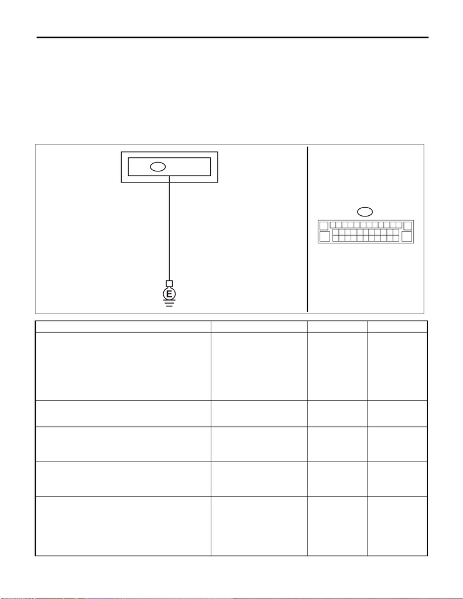

VDC(diag)-54

Diagnostic Procedure with Diagnostic Trouble Code (DTC)

VEHICLE DYNAMICS CONTROL (VDC) (DIAGNOSTICS)

U: DTC C1411 ECU

DTC DETECTING CONDITION:

Judge as malfunction when ECM internal malfunction is detected.

TROUBLE SYMPTOM:

• ABS does not operate sometimes.

• EBD does not operate sometimes.

• VDC does not operate.

• Hill start assist does not operate.

WIRING DIAGRAM:

Vehicle dynamics control system <Ref. to WI-412, Vehicle Dynamics Control System.>

Step Check Yes No

1 CHECK VDCCM&H/U GROUND CIRCUIT.

1) Turn the ignition switch to OFF.

2) Disconnect the connector from the

VDCCM&H/U.

3) Measure the resistance between

VDCCM&H/U and chassis ground.

Connector & terminal

(B310) No. 38 — Chassis ground:

Is the resistance less than 10

Ω?

Go to step 2. Repair the

VDCCM&H/U

ground harness.

2 CHECK POOR CONTACT OF CONNEC-

TORS.

Is there poor contact of the con-

nector between the battery, igni-

tion switch and VDCCM&H/U?

Repair the connec-

tor.

Go to step 3.

3 CHECK CAUSE OF SIGNAL NOISE. Are the radio wave devices and

electronic components

installed correctly?

Go to step 4. Install the radio

wave devices and

electronic compo-

nents properly.

4 CHECK CAUSE OF SIGNAL NOISE. Is there a noise source (such as

an antenna) installed near the

sensor harness and VDCCM?

Install the noise

sources apart from

sensor harness

and VDCCM.

Go to step 5.

5 CHECK VDCCM&H/U.

1) Connect all connectors.

2) Perform the Clear Memory Mode. <Ref. to

VDC(diag)-23, Clear Memory Mode.>

3) Perform the Inspection Mode. <Ref. to

VDC(diag)-22, Inspection Mode.>

4) Read the DTC.

Is the same DTC displayed? Replace the

VDCCM&H/U.

<Ref. to VDC-8,

VDC Control Mod-

ule and Hydraulic

Control Unit

(VDCCM&H/U).>

Go to step 6.

B310

1

10 11 12 13

14

15

26

16 17 18 19 20 21 22 23 24 25

27 28 29 30 31 32 33 34 35 36 37

38

38

B310

VDC01278

VDC CM

[figure not shown]

VDC(diag)-55

Diagnostic Procedure with Diagnostic Trouble Code (DTC)

VEHICLE DYNAMICS CONTROL (VDC) (DIAGNOSTICS)

6 CHECK OTHER DTC DETECTION. Is any other DTC displayed? Perform the diag-

nosis according to

DTC. <Ref. to

VDC(diag)-42, List

of Diagnostic Trou-

ble Code (DTC).>

Temporary poor

contact occurs.

Step Check Yes No

[figure not shown]

VDC(diag)-56

Diagnostic Procedure with Diagnostic Trouble Code (DTC)

VEHICLE DYNAMICS CONTROL (VDC) (DIAGNOSTICS)

V: DTC C1412 PARAMETER SELECTION ERROR

DTC DETECTING CONDITION:

• A fault is detected if abnormal set value is found on the vehicle model that were given some parameters.

• A fault is detected if 0 point setting compensation of the sensor is not yet performed.

TROUBLE SYMPTOM:

• ABS does not operate.

• VDC does not operate.

• Hill start assist does not operate.

NOTE:

When the VDCCM&H/U is replaced, this DTC may be stored.

Step Check Yes No

1 CHECK VDCCM&H/U IDENTIFICATION

SYMBOL.

Check the identification symbol attached on the

H/U. <Ref. to VDC-2, SPECIFICATION, Gen-

eral Description.>

Is the identification symbol cor-

rect?

Go to step 2. Replace the

VDCCM&H/U.

<Ref. to VDC-8,

VDC Control Mod-

ule and Hydraulic

Control Unit

(VDCCM&H/U).>

2 CHECK PARAMETER SELECTED IN VDC-

CM.

<Ref. to VDC(diag)-18, READ PARAMETER,

OPERATION, Subaru Select Monitor.>

Does the parameter registered

in the VDCCM match the rele-

vant vehicle?

Replace the

VDCCM&H/U.

<Ref. to VDC-8,

VDC Control Mod-

ule and Hydraulic

Control Unit

(VDCCM&H/U).>

Select and register

the correct param-

eter. <Ref. to

VDC(diag)-17,

PARAMETER

SELECTION,

OPERATION, Sub-

aru Select Moni-

tor.>

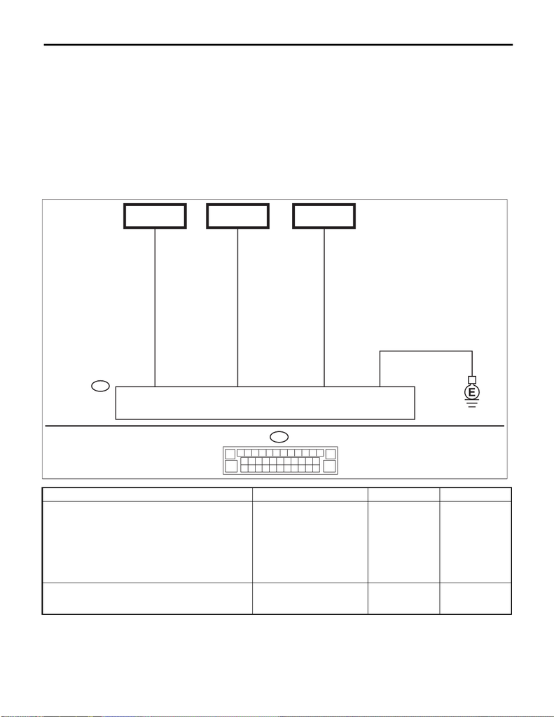

VDC(diag)-57

Diagnostic Procedure with Diagnostic Trouble Code (DTC)

VEHICLE DYNAMICS CONTROL (VDC) (DIAGNOSTICS)

W: DTC C1413 POWER SUPPLY VOLTAGE FAILURE

DTC DETECTING CONDITION:

A fault is detected if the power supply voltage is out of normal range for a predetermined time or more.

TROUBLE SYMPTOM:

• ABS does not operate.

• EBD may not operate.

• VDC does not operate.

• Hill start assist does not operate.

NOTE:

Warning lights go off if voltage returns.

WIRING DIAGRAM:

Vehicle dynamics control system <Ref. to WI-412, Vehicle Dynamics Control System.>

Step Check Yes No

1 CHECK GENERATOR.

1) Start the engine.

2) Run the engine at idle after warming up.

3) Measure the voltage between generator ter-

minal B and chassis ground.

Terminals

Generator terminal B (+) — Chassis

ground (–):

Is the voltage 10 — 15 V? Go to step 2. Repair the genera-

tor.

2 CHECK BATTERY TERMINAL.

Turn the ignition switch to OFF.

Are the positive and negative

battery terminals installed

tightly?

Go to step 3. Install the battery

terminal correctly.

1

31

26

38

B310

B310

10 11 12 13

14

15

26

16 17 18 19 20 21 22 23 24 25

27 28 29 30 31 32 33 34 35 36 37

1

38

VDC01277

MB-1

SBF-1

(B)

VDC CM

MB-2

M/B FUSE NO. 1

(B)

FB-44

F/B FUSE NO. 33

(IG)

[figure not shown]

VDC(diag)-58

Diagnostic Procedure with Diagnostic Trouble Code (DTC)

VEHICLE DYNAMICS CONTROL (VDC) (DIAGNOSTICS)

3 CHECK VDCCM&H/U INPUT VOLTAGE.

1) Disconnect the connector from the

VDCCM&H/U.

2) Run the engine at idle.

3) Operate devices such as headlights, air

conditioner, rear defogger, etc. which produce

an electrical load.

4) Measure the voltage between VDCCM&H/U

connector and chassis ground.

Connector & terminal

(B310) No. 1 (+) — (B310) No. 38 (–):

(B310) No. 26 (+) — (B310) No. 38 (–):

(B310) No. 31 (+) — (B310) No. 38 (–):

Is the voltage 10 — 15 V? Go to step 4. Repair the power

supply circuit.

4 CHECK VDCCM&H/U GROUND CIRCUIT.

1) Turn the ignition switch to OFF.

2) Measure the resistance between

VDCCM&H/U connector and chassis ground.

Connector & terminal

(B310) No. 38 — Chassis ground:

Is the resistance less than 10

Ω?

Go to step 5. Repair the

VDCCM&H/U

ground harness

circuit.

5 CHECK POOR CONTACT OF CONNEC-

TORS.

Is there poor contact of connec-

tor between generator, battery

and VDCCM&H/U?

Repair the connec-

tor.

Go to step 6.

6 CHECK VDCCM&H/U.

1) Connect all connectors.

2) Perform the Clear Memory Mode. <Ref. to

VDC(diag)-23, Clear Memory Mode.>

3) Perform the Inspection Mode. <Ref. to

VDC(diag)-22, Inspection Mode.>

4) Read the DTC.

Is the same DTC displayed? Replace the

VDCCM&H/U.

<Ref. to VDC-8,

VDC Control Mod-

ule and Hydraulic

Control Unit

(VDCCM&H/U).>

Go to step 7.

7 CHECK OTHER DTC DETECTION. Is any other DTC displayed? Perform the diag-

nosis according to

DTC. <Ref. to

VDC(diag)-42, List

of Diagnostic Trou-

ble Code (DTC).>

Temporary poor

contact occurs.

Step Check Yes No

[figure not shown]

VDC(diag)-59

Diagnostic Procedure with Diagnostic Trouble Code (DTC)

VEHICLE DYNAMICS CONTROL (VDC) (DIAGNOSTICS)

X: DTC C1422 VDC INTERRUPTION FOR ENGINE CONVENIENCE

DTC DETECTING CONDITION:

A fault is detected if engine control prohibition flag from ECM is received.

TROUBLE SYMPTOM:

• VDC does not operate.

• Hill start assist does not operate.

NOTE:

Warning lights go off if the cooperation control of ECM returns.

Step Check Yes No

1 CHECK COOPERATION CONTROL FEASI-

BILITY OF ECM USING SUBARU SELECT

MONITOR.

1) Start the engine, and run the engine at idle

approximately 5 minutes.

2) Connect Subaru Select Monitor, and select

“Current Data Display & Save”.

3) Check «E/G Control Stop Flag» and «E/G

torques up Control Stop Flag» on the display.

Does the «E/G Control Stop

Flag» indicate “1”?

Go to step 4. Go to step 2.

2 CHECK WARNING LIGHT.

Check whether the VDC warning light illumi-

nates after driving for 1 minute or more at a

speed of 10 km/h (6 MPH) or more.

Does the VDC warning light illu-

minate?

Go to step 3. VDC is normal.

Perform the Clear

Memory Mode.

NOTE:

DTC may be re-

corded if cranking

is performed dur-

ing driving.

3 CHECK POOR CONTACT OF CONNEC-

TORS.

Is there poor contact of ECM

connector?

Repair the connec-

tor.

Go to step 4.

4 CHECK ECM.

Refer to the basic diagnostic procedure of

ENGINE (DIAGNOSTICS).

Is ECM normal? Go to step 5. Replace the ECM.

<Ref. to FU(w/o

STI)-132, Engine

Control Module

(ECM).> <Ref. to

FU(STI)-56,

Engine Control

Module (ECM).>

5 CHECK VDCCM&H/U.

1) Connect all connectors.

2) Perform the Clear Memory Mode. <Ref. to

VDC(diag)-23, Clear Memory Mode.>

3) Perform the Inspection Mode. <Ref. to

VDC(diag)-22, Inspection Mode.>

4) Read the DTC.

Is the same DTC displayed? Replace the

VDCCM&H/U.

<Ref. to VDC-8,

VDC Control Mod-

ule and Hydraulic

Control Unit

(VDCCM&H/U).>

Go to step 6.

6 CHECK OTHER DTC DETECTION. Is any other DTC displayed? Perform the diag-

nosis according to

DTC. <Ref. to

VDC(diag)-42, List

of Diagnostic Trou-

ble Code (DTC).>

It results from a

temporary noise

interference.

[figure not shown]

VDC(diag)-60

Diagnostic Procedure with Diagnostic Trouble Code (DTC)

VEHICLE DYNAMICS CONTROL (VDC) (DIAGNOSTICS)

Y: DTC C1423 DIFFERENT ECU SPECIFICATIONS

DTC DETECTING CONDITION:

A fault is detected if the vehicle type information obtained from ECM via communication is different from the

parameter setting information.

TROUBLE SYMPTOM:

• ABS does not operate.

• VDC does not operate.

• Hill start assist does not operate.

NOTE:

When parameter selection for VDCCM is improper, this DTC may be memorized.

Step Check Yes No

1 CHECK VDCCM&H/U IDENTIFICATION

SYMBOL.

Check the identification symbol attached on the

H/U. <Ref. to VDC-2, SPECIFICATION, Gen-

eral Description.>

Is the identification symbol cor-

rect?

Go to step 2. Replace the

VDCCM&H/U.

<Ref. to VDC-8,

VDC Control Mod-

ule and Hydraulic

Control Unit

(VDCCM&H/U).>

2 CHECK PARAMETER SELECTED IN VDC-

CM.

<Ref. to VDC(diag)-18, READ PARAMETER,

OPERATION, Subaru Select Monitor.>

Does the parameter registered

in the VDCCM match the rele-

vant vehicle?

CVT model: Go to

step 3.

MT model: Go to

step 5.

Select and register

the correct param-

eter. <Ref. to

VDC(diag)-17,

PARAMETER

SELECTION,

OPERATION, Sub-

aru Select Moni-

tor.>

3 CHECK TCM SPECIFICATION.

Check the TCM specification.

Is the specification of TCM

same as vehicle specification?

Go to step 4. Replace the TCM.

<Ref. to

CVT(TR690)-126,

Transmission Con-

trol Module

(TCM).>

4 CHECK CVT SYSTEM.

1) Start the engine.

2) Check the DTC in CVT system.

Is DTC of CVT system dis-

played?

Perform the diag-

nosis according to

DTC. <Ref. to

CVT(diag)-32, List

of Diagnostic Trou-

ble Code (DTC).>

Go to step 5.

5 CHECK ECM SPECIFICATION.

Check the ECM specification.

Is the specification of ECM

same as vehicle specification?

Go to step 6. Replace the ECM.

<Ref. to FU(w/o

STI)-132, Engine

Control Module

(ECM).> <Ref. to

FU(STI)-56,

Engine Control

Module (ECM).>

6 CHECK VDCCM&H/U.

1) Connect all connectors.

2) Perform the Clear Memory Mode. <Ref. to

VDC(diag)-23, Clear Memory Mode.>

3) Perform the Inspection Mode. <Ref. to

VDC(diag)-22, Inspection Mode.>

4) Read the DTC.

Is the same DTC displayed? Replace the

VDCCM&H/U.

<Ref. to VDC-8,

VDC Control Mod-

ule and Hydraulic

Control Unit

(VDCCM&H/U).>

Go to step 7.

[figure not shown]

VDC(diag)-61

Diagnostic Procedure with Diagnostic Trouble Code (DTC)

VEHICLE DYNAMICS CONTROL (VDC) (DIAGNOSTICS)

7 CHECK OTHER DTC DETECTION. Is any other DTC displayed? Perform the diag-

nosis according to

DTC. <Ref. to

VDC(diag)-42, List

of Diagnostic Trou-

ble Code (DTC).>

It results from a

temporary noise

interference.

Step Check Yes No

[figure not shown]

VDC(diag)-62

Diagnostic Procedure with Diagnostic Trouble Code (DTC)

VEHICLE DYNAMICS CONTROL (VDC) (DIAGNOSTICS)

Z: DTC C1424 ECM FAILURE

DTC DETECTING CONDITION:

A fault is detected if malfunction judgment flag for the engine system is received from ECM for a predeter-

mined time or more.

TROUBLE SYMPTOM:

Hill start assist does not operate.

Step Check Yes No

1 CHECK ECM.

1) Start the engine.

2) Check DTC of ECM.

Is DTC displayed? Perform the diag-

nosis according to

DTC.

Go to step 2.

2 CHECK VDCCM&H/U.

1) Connect all connectors.

2) Perform the Clear Memory Mode. <Ref. to

VDC(diag)-23, Clear Memory Mode.>

3) Perform the Inspection Mode. <Ref. to

VDC(diag)-22, Inspection Mode.>

4) Read the DTC.

Is the same DTC displayed? Replace the

VDCCM&H/U.

<Ref. to VDC-8,

VDC Control Mod-

ule and Hydraulic

Control Unit

(VDCCM&H/U).>

Go to step 3.

3 CHECK OTHER DTC DETECTION. Is any other DTC displayed? Perform the diag-

nosis according to

DTC. <Ref. to

VDC(diag)-42, List

of Diagnostic Trou-

ble Code (DTC).>

It results from a

temporary noise

interference.

[figure not shown]

VDC(diag)-63

Diagnostic Procedure with Diagnostic Trouble Code (DTC)

VEHICLE DYNAMICS CONTROL (VDC) (DIAGNOSTICS)

AA:DTC C1431 AT ABNORMAL

DTC DETECTING CONDITION:

A fault is detected if malfunction flag is received from TCM.

TROUBLE SYMPTOM:

• VDC does not operate.

• Hill start assist does not operate.

Step Check Yes No

1 CHECK TCM.

1) Start the engine.

2) Check DTC of TCM.

Is DTC displayed? Perform the diag-

nosis according to

DTC. <Ref. to

CVT(diag)-32, List

of Diagnostic Trou-

ble Code (DTC).>

Go to step 2.

2 CHECK VDCCM&H/U.

1) Turn the ignition switch to OFF.

2) After turning the ignition switch to ON for

approx. 10 seconds, turn it to OFF.

3) Turn the ignition switch to ON again.

4) Connect all connectors.

5) Perform the Clear Memory Mode. <Ref. to

VDC(diag)-23, Clear Memory Mode.>

6) Perform the Inspection Mode. <Ref. to

VDC(diag)-22, Inspection Mode.>

7) Read the DTC.

Is the same DTC displayed? Replace the

VDCCM&H/U.

<Ref. to VDC-8,

VDC Control Mod-

ule and Hydraulic

Control Unit

(VDCCM&H/U).>

Go to step 3.

3 CHECK OTHER DTC DETECTION. Is any other DTC displayed? Perform the diag-

nosis according to

DTC. <Ref. to

VDC(diag)-42, List

of Diagnostic Trou-

ble Code (DTC).>

It results from a

temporary noise

interference.

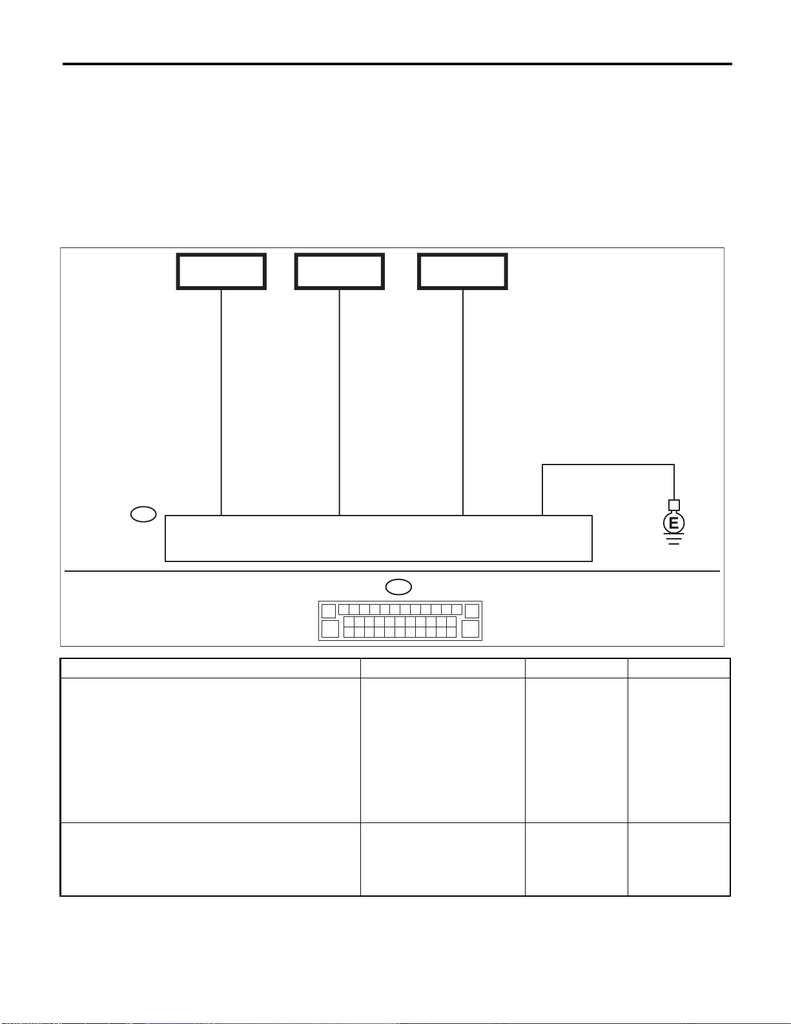

VDC(diag)-64

Diagnostic Procedure with Diagnostic Trouble Code (DTC)

VEHICLE DYNAMICS CONTROL (VDC) (DIAGNOSTICS)

AB:DTC C1511 VALVE RELAY

DTC DETECTING CONDITION:

A fault is detected if valve relay drive voltage failure is detected.

TROUBLE SYMPTOM:

• ABS does not operate.

• EBD does not operate.

• VDC does not operate.

• Hill start assist does not operate.

WIRING DIAGRAM:

Vehicle dynamics control system <Ref. to WI-412, Vehicle Dynamics Control System.>

Step Check Yes No

1 CHECK VDCCM&H/U INPUT VOLTAGE.

1) Turn the ignition switch to OFF.

2) Disconnect the connector from the

VDCCM&H/U.

3) Run the engine at idle.

4) Measure the voltage between VDCCM&H/U

connector and chassis ground.

Connector & terminal

(B310) No. 1 (+) — Chassis ground (–):

(B310) No. 31 (+) — Chassis ground (–):

Is the voltage 10 — 15 V? Go to step 2. Repair the power

supply circuit.

2 CHECK VDCCM&H/U INPUT VOLTAGE.

Calculate the voltage difference measured in

step 1.

A: (B310) No. 1 (+) — Chassis ground (–):

B: (B310) No. 31 (+) — Chassis ground (–):

Is the voltage difference

between A and B 2 V or more?

Repair the power

supply circuit.

Go to step 3.

1

31

26

38

B310

B310

10 11 12 13

14

15

26

16 17 18 19 20 21 22 23 24 25

27 28 29 30 31 32 33 34 35 36 37

1

38

VDC01277

MB-1

SBF-1

(B)

VDC CM

MB-2

M/B FUSE NO. 1

(B)

FB-44

F/B FUSE NO. 33

(IG)

[figure not shown]

VDC(diag)-65

Diagnostic Procedure with Diagnostic Trouble Code (DTC)

VEHICLE DYNAMICS CONTROL (VDC) (DIAGNOSTICS)

3 CHECK VDCCM&H/U GROUND CIRCUIT.

1) Turn the ignition switch to OFF.

2) Measure the resistance between

VDCCM&H/U connector and chassis ground.

Connector & terminal

(B310) No. 38 — Chassis ground:

Is the resistance less than 10

Ω?

Go to step 4. Repair the

VDCCM&H/U

ground harness.

4 CHECK POOR CONTACT OF CONNEC-

TORS.

Is there poor contact of connec-

tor between generator, battery

and VDCCM&H/U?

Repair the connec-

tor.

Go to step 5.

5 CHECK VDCCM&H/U.

1) Connect all connectors.

2) Perform the Clear Memory Mode. <Ref. to

VDC(diag)-23, Clear Memory Mode.>

3) Perform the Inspection Mode. <Ref. to

VDC(diag)-22, Inspection Mode.>

4) Read the DTC.

Is the same DTC displayed? Replace the

VDCCM&H/U.

<Ref. to VDC-8,

VDC Control Mod-

ule and Hydraulic

Control Unit

(VDCCM&H/U).>

Go to step 6.

6 CHECK OTHER DTC DETECTION. Is any other DTC displayed? Perform the diag-

nosis according to

DTC. <Ref. to

VDC(diag)-42, List

of Diagnostic Trou-

ble Code (DTC).>

Temporary poor

contact occurs.

Step Check Yes No

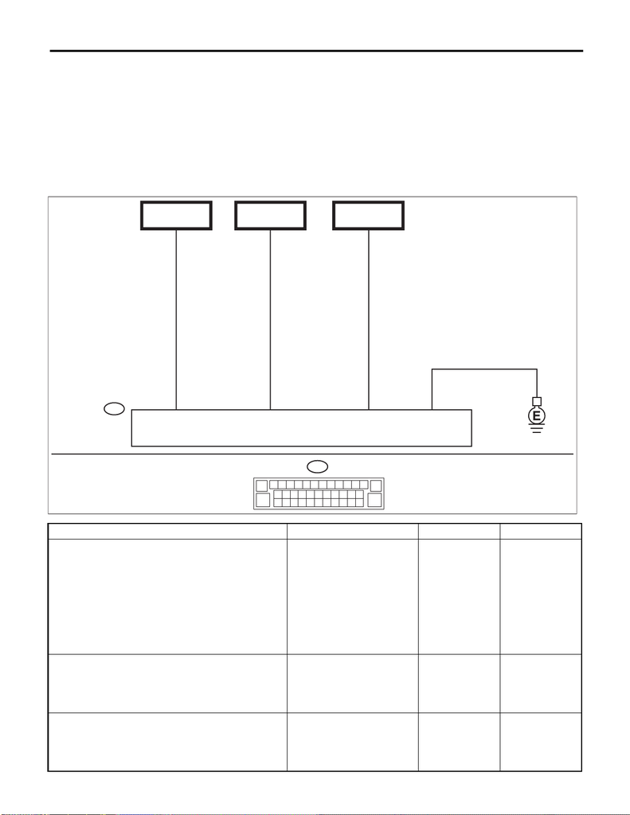

VDC(diag)-66

Diagnostic Procedure with Diagnostic Trouble Code (DTC)

VEHICLE DYNAMICS CONTROL (VDC) (DIAGNOSTICS)

AC:DTC C1521 MOTOR RELAY

DTC DETECTING CONDITION:

A fault is detected if the pump motor supply voltage becomes significantly low when the pump motor is not

driven.

TROUBLE SYMPTOM:

• ABS does not operate sometimes.

• VDC does not operate.

• Hill start assist does not operate.

WIRING DIAGRAM:

Vehicle dynamics control system <Ref. to WI-412, Vehicle Dynamics Control System.>

Step Check Yes No

1 CHECK VDCCM&H/U INPUT VOLTAGE.

1) Turn the ignition switch to OFF.

2) Disconnect the connector from the

VDCCM&H/U.

3) Turn the ignition switch to ON.

4) Measure the voltage between VDCCM&H/U

connector and chassis ground.

Connector & terminal

(B310) No. 26 (+) — Chassis ground (–):

(B310) No. 31 (+) — Chassis ground (–):

Is the voltage 10 — 15 V? Go to step 2. Repair the

VDCCM&H/U

power supply cir-

cuit.

2 CHECK VDCCM&H/U INPUT VOLTAGE.

Calculate the voltage difference measured in

step 1.

A: (B310) No. 26 (+) — Chassis ground (–):

B: (B310) No. 31 (+) — Chassis ground (–):

Is the voltage difference

between A and B 2 V or more?

Repair the power

supply circuit.

Go to step 3.

3 CHECK INSTALLATION OF VDCCM&H/U

GROUND.

Is the VDCCM&H/U ground ter-

minal installation bolt installed

correctly?

Go to step 4. Install the

VDCCM&H/U

ground terminal

installation bolt

correctly.

1

31

26

38

B310

B310

10 11 12 13

14

15

26

16 17 18 19 20 21 22 23 24 25

27 28 29 30 31 32 33 34 35 36 37

1

38

VDC01277

MB-1

SBF-1

(B)

VDC CM

MB-2

M/B FUSE NO. 1

(B)

FB-44

F/B FUSE NO. 33

(IG)

[figure not shown]

VDC(diag)-67

Diagnostic Procedure with Diagnostic Trouble Code (DTC)

VEHICLE DYNAMICS CONTROL (VDC) (DIAGNOSTICS)

4 CHECK VDCCM&H/U GROUND CIRCUIT.

1) Turn the ignition switch to OFF.

2) Measure the resistance between

VDCCM&H/U connector and chassis ground.

Connector & terminal

(B310) No. 38 — Chassis ground:

Is the resistance less than 10

Ω?

Go to step 5. Repair the

VDCCM&H/U

ground harness.

5 CHECK VDCCM&H/U MOTOR RELAY.

Measure the resistance between VDCCM&H/U

terminals.

Terminals

No. 26 — No. 38:

Is the resistance 1 MΩ or

more?

Go to step 6. Replace the

VDCCM&H/U.

<Ref. to VDC-8,

VDC Control Mod-

ule and Hydraulic

Control Unit

(VDCCM&H/U).>

6 CHECK POOR CONTACT OF CONNEC-

TORS.

Turn the ignition switch to OFF.

Is there poor contact of connec-

tor between generator, battery

and VDCCM&H/U?

Repair the connec-

tor.

Go to step 7.

7 CHECK VDCCM&H/U.

1) Connect all connectors.

2) Perform the Clear Memory Mode. <Ref. to

VDC(diag)-23, Clear Memory Mode.>

3) Perform the Inspection Mode. <Ref. to

VDC(diag)-22, Inspection Mode.>

4) Read the DTC.

Is the same DTC displayed? Replace the

VDCCM&H/U.

<Ref. to VDC-8,

VDC Control Mod-

ule and Hydraulic

Control Unit

(VDCCM&H/U).>

Go to step 8.

8 CHECK OTHER DTC DETECTION. Is any other DTC displayed? Perform the diag-

nosis according to

DTC. <Ref. to

VDC(diag)-42, List

of Diagnostic Trou-

ble Code (DTC).>

Temporary poor

contact occurs.

NOTE:

Though the ABS

warning light, and

the VDC warning

light & VDC indica-

tor light may re-

main lit at this

point, this is nor-

mal. Drive the vehi-

cle at 40 km/h (25

MPH) or more in

order to turn off the

ABS warning light,

and the VDC warn-

ing light & VDC in-

dicator light. Be

sure to drive the

vehicle and check

that the warning

light goes off.

Step Check Yes No

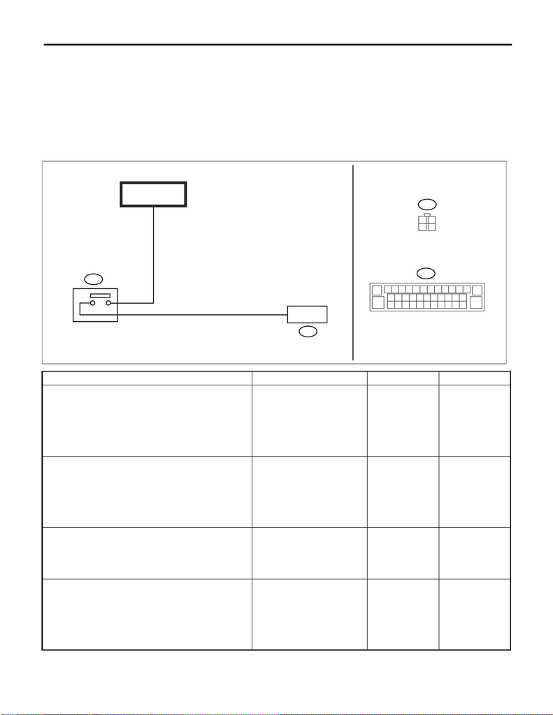

VDC(diag)-68

Diagnostic Procedure with Diagnostic Trouble Code (DTC)

VEHICLE DYNAMICS CONTROL (VDC) (DIAGNOSTICS)

AD:DTC C1531 BLS OFF FAULT

DTC DETECTING CONDITION:

A fault is detected if stop light switch signal is OFF for a predetermined time or more with the pressure signal

of the pressure sensor high.

TROUBLE SYMPTOM:

• VDC does not operate.

• Hill start assist does not operate.

WIRING DIAGRAM:

Stop light system <Ref. to WI-397, ENGINE TYPE FA, WIRING DIAGRAM, Stop Light System.>

Step Check Yes No

1 CHECK STOP LIGHT SWITCH.

1) Check the stop light switch. <Ref. to BR-77,

INSTALLATION, Stop Light Switch.>

Is the installation position of the

stop light switch correct?

Go to step 2. Adjust the installa-

tion position of the

stop light switch.

<Ref. to BR-77,

INSTALLATION,

Stop Light

Switch.>

2 CHECK STOP LIGHT SWITCH.

1) Turn the ignition switch to OFF.

2) Disconnect the stop light switch connector.

3) Measure the resistance of stop light switch

terminals.

Connector & terminal

(B65) No. 1 — No. 2:

Is the resistance 1 Ω or less

when the stop light switch is ON

(when pedal is depressed)?

Go to step 3. Replace the stop

light switch. <Ref.

to BR-77, Stop

Light Switch.>

3 CHECK STOP LIGHT POWER SUPPLY.

Measure the voltage between stop light switch

terminal and chassis ground.

Connector & terminal

(B65) No. 1 (+) — Chassis ground (–):

Is the voltage 10 — 15 V? Go to step 4. Repair the stop

light power supply

circuit.

4 CHECK STOP LIGHT SWITCH HARNESS.

1) Disconnect the connector from the

VDCCM&H/U.

2) Measure the resistance between

VDCCM&H/U and stop light switch.

Connector & terminal

(B65) No. 2 — (B310) No. 27:

Is the resistance less than 1 Ω? Go to step 5. Repair the stop

light switch circuit.

B65

12

34

27

B310

B65

1

2

B310

10 11 12 13

14

15

26

16 17 18 19 20 21 22 23 24 25

27 28 29 30 31 32 33 34 35 36 37

1

38

VDC01280

VDC CM

STOP LIGHT &

BRAKE SWITCH

FB-3

F/B FUSE NO. 8

(B)

[figure not shown]

VDC(diag)-69

Diagnostic Procedure with Diagnostic Trouble Code (DTC)

VEHICLE DYNAMICS CONTROL (VDC) (DIAGNOSTICS)

5 CHECK POOR CONTACT OF CONNEC-

TORS.

Is there poor contact of connec-

tor between stop light switch

and VDCCM&H/U?

Repair the connec-

tor.

Go to step 6.

6 CHECK VDCCM&H/U.

1) Connect all connectors.

2) Perform the Clear Memory Mode. <Ref. to

VDC(diag)-23, Clear Memory Mode.>

3) Perform the Inspection Mode. <Ref. to

VDC(diag)-22, Inspection Mode.>

4) Read the DTC.

Is the same DTC displayed? Replace the

VDCCM&H/U.

<Ref. to VDC-8,

VDC Control Mod-

ule and Hydraulic

Control Unit

(VDCCM&H/U).>

Go to step 7.

7 CHECK OTHER DTC DETECTION. Is any other DTC displayed? Perform the diag-

nosis according to

DTC. <Ref. to

VDC(diag)-42, List

of Diagnostic Trou-

ble Code (DTC).>

Temporary poor

contact occurs.

Step Check Yes No

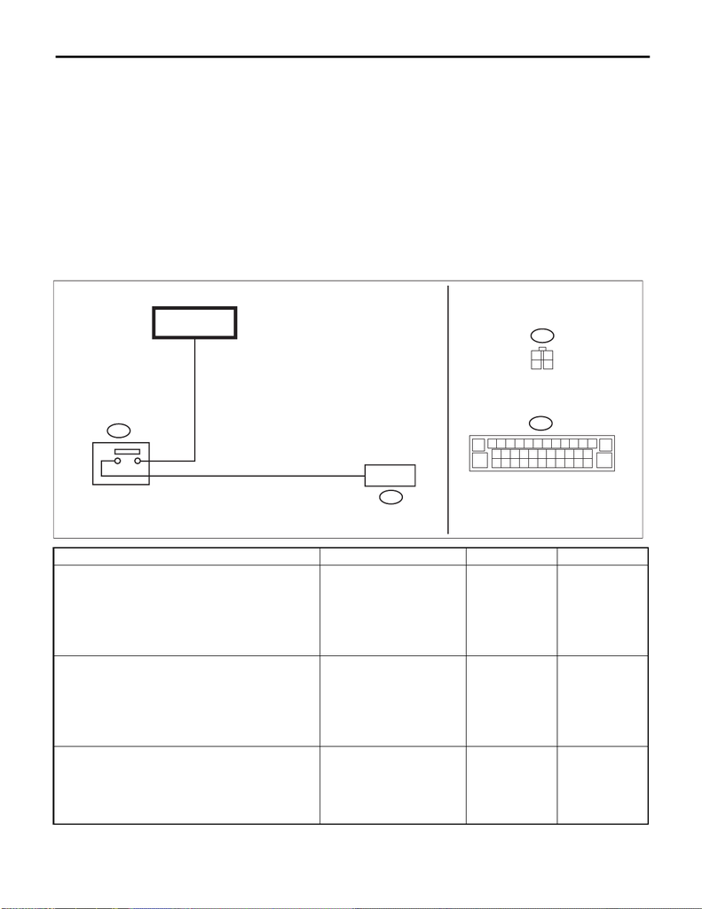

VDC(diag)-70

Diagnostic Procedure with Diagnostic Trouble Code (DTC)

VEHICLE DYNAMICS CONTROL (VDC) (DIAGNOSTICS)

AE:DTC C1532 BLS ON FAULT

DTC DETECTING CONDITION:

• A fault is detected if a change of the vehicle speed from high to low occurs for a predetermined number of

times or more, while a change of the stop light switch from OFF to ON is not detected.

• A fault is detected if stop light switch ON status continues for long time while the vehicle speed is at the pre-

determined speed or higher.

TROUBLE SYMPTOM:

• VDC does not operate.

• Hill start assist does not operate.

NOTE:

If the pressure sensor is defective, this DTC may probably be recorded in addition to pressure sensor mal-

function.

WIRING DIAGRAM:

Stop light system <Ref. to WI-397, ENGINE TYPE FA, WIRING DIAGRAM, Stop Light System.>

Step Check Yes No

1 CHECK STOP LIGHT SWITCH.

1) Turn the ignition switch to OFF.

2) Disconnect the stop light switch connector.

3) Measure the resistance of stop light switch

terminals.

Connector & terminal

(B65) No. 1 — No. 2:

Is the resistance 1 MΩ or more

when stop light switch is OFF

(when pedal is not depressed)?

Go to step 2. Replace the stop

light switch. <Ref.

to BR-77, Stop

Light Switch.>

2 CHECK STOP LIGHT SWITCH HARNESS.

1) Disconnect the connector from the

VDCCM&H/U.

2) Measure the resistance between

VDCCM&H/U connector and chassis ground.

Connector & terminal

(B310) No. 27 — Chassis ground:

Go to step 3. Repair the stop

light switch circuit.

3 INTERVIEW CUSTOMERS.

Make sure that the operation was performed in

which accelerator pedal and brake pedal were

depressed simultaneously (with depressing

brake pedal with left foot).

Were the acceleration pedal

and brake pedal depressed

simultaneously?

System is normal.

(DTC may be

recorded if the

brake pedal is

always depressed

while driving.)

Go to step 4.

B65

12

34

27

B310

B65

1

2

B310

10 11 12 13

14

15

26

16 17 18 19 20 21 22 23 24 25

27 28 29 30 31 32 33 34 35 36 37

1

38

VDC01280

VDC CM

STOP LIGHT &

BRAKE SWITCH

FB-3

F/B FUSE NO. 8

(B)

VDC(diag)-71

Diagnostic Procedure with Diagnostic Trouble Code (DTC)

VEHICLE DYNAMICS CONTROL (VDC) (DIAGNOSTICS)

4 CHECK VDCCM&H/U.

1) Connect all connectors.

2) Perform the Clear Memory Mode. <Ref. to

VDC(diag)-23, Clear Memory Mode.>

3) Perform the Inspection Mode. <Ref. to

VDC(diag)-22, Inspection Mode.>

4) Read the DTC.

Is the same DTC displayed? Replace the

VDCCM&H/U.

<Ref. to VDC-8,

VDC Control Mod-

ule and Hydraulic

Control Unit

(VDCCM&H/U).>

Go to step 5.

5 CHECK OTHER DTC DETECTION. Is any other DTC displayed? Perform the diag-

nosis according to

DTC. <Ref. to

VDC(diag)-42, List

of Diagnostic Trou-

ble Code (DTC).>

Temporary poor

contact occurs.

Step Check Yes No

[figure not shown]

VDC(diag)-72

Diagnostic Procedure with Diagnostic Trouble Code (DTC)

VEHICLE DYNAMICS CONTROL (VDC) (DIAGNOSTICS)

AF:DTC C1711 STEERING ANGLE SENSOR ABNORMAL

DTC DETECTING CONDITION:

• A fault is detected if the sensor signal value is not correct.

• A fault is detected if the yaw rate sensor signal / lateral G sensor signal change while the sensor signal of

steering angle sensor indicates a constant value.

• A fault is detected if the communication status of steering angle sensor is abnormal.

TROUBLE SYMPTOM:

• ABS does not operate.

• VDC does not operate.

• Hill start assist does not operate.

WIRING DIAGRAM:

Vehicle dynamics control system <Ref. to WI-412, Vehicle Dynamics Control System.>

i233

i232

78

5

6

34

21

i229

12 345

6789

10 11 12

i233

J/C

1

1

1

I/F

B281B:

i84C:

B20

C35

C27

B28

1

VDC01281

i84

19

18

21

20

17

1

23

4

56

27

28 29 30

31 32 33 34 35

798

C:

B231

2

B310

10 11 12 13

14

15

26

16 17 18 19 20 21 22 23 24 25

27 28 29 30 31 32 33 34 35 36 37

1

38

B:

B281

29

10 11

12 13 14 15

2524

16

30

98

17 18 19

20

28

21 22 23

3231

26 27

33 34 35

B231

1

35

36

i232

J/C

1

6

2

3

B310

7

i229

B551

4

VDC CM

FB-44

F/B FUSE NO. 33

(IG)

BODY INTEGRATED UNIT

STEERING ANGLE SENSOR

: TERMINAL No. OPTIONAL ARRANGEMENT

[figure not shown]

VDC(diag)-73

Diagnostic Procedure with Diagnostic Trouble Code (DTC)

VEHICLE DYNAMICS CONTROL (VDC) (DIAGNOSTICS)

Step Check Yes No

1 CHECK POWER SUPPLY FOR STEERING

ANGLE SENSOR.

1) Turn the ignition switch to OFF.

2) Disconnect the connector from steering

angle sensor.

3) Turn the ignition switch to ON.

4) Measure the voltage between steering

angle sensor and chassis ground.

Connector & terminal

(B231) No. 4 (+) — Chassis ground (–):

Is the voltage 10 — 15 V? Go to step 2. Repair the steering

angle sensor

power supply cir-

cuit.

2 CHECK GROUND CIRCUIT OF STEERING

ANGLE SENSOR.

Measure the resistance between steering angle

sensor and chassis ground.

Connector & terminal

(B231) No. 1 — Chassis ground:

Is the resistance less than 10

Ω?

Go to step 3. Repair ground cir-

cuit in the steering

angle sensor.

3 CHECK STEERING ANGLE SENSOR HAR-

NESS.

1) Disconnect the connector from the

VDCCM&H/U.

2) Measure the resistance between

VDCCM&H/U and steering angel sensor.

Connector & terminal

(B231) No. 2 — (B310) No. 35:

(B231) No. 3 — (B310) No. 36:

Is the resistance less than 1 Ω? Go to step 4. Repair the harness

between the steer-

ing angle sensor

and VDCCM&H/U.

4 CHECK GROUND SHORT CIRCUIT OF

STEERING ANGLE SENSOR HARNESS.

Measure the resistance between steering angle

sensor and chassis ground.

Connector & terminal

(B231) No. 2 — Chassis ground:

(B231) No. 3 — Chassis ground:

Is the resistance 10 Ω or more? Go to step 5. Repair the harness

between the steer-

ing angle sensor

and VDCCM&H/U.

5 CHECK STEERING WHEEL.

1) Drive the vehicle on a flat road.

2) Park the vehicle straight.

3) Check the steering wheel for deviation from

center.

Is the deviation from the center

of steering wheel less than 5°?

Go to step 6. Perform the cen-

tering adjustment

of steering wheel,

and perform the

VDC sensor mid-

point setting mode.

<Ref. to VDC-16,

VDC SENSOR

MIDPOINT SET-

TING MODE,

ADJUSTMENT,

VDC Control Mod-

ule and Hydraulic

Control Unit

(VDCCM&H/U).>

6 CHECK OUTPUT OF STEERING ANGLE

SENSOR USING SUBARU SELECT MONI-

TOR.

1) Adjust steering wheel to the center position.

2) Connect Subaru Select Monitor, and select

“Current Data Display & Save”.

3) Read the «Steering Angle Sensor» dis-

played on display.

Is the indicated reading of the

«Steering Angle Sensor» on

the monitor display –10° —

10°?

Perform the VDC

sensor midpoint

setting mode. Go

to step 7. <Ref. to

VDC-16, VDC

SENSOR MID-

POINT SETTING

MODE, ADJUST-

MENT, VDC Con-

trol Module and

Hydraulic Control

Unit (VDCCM&H/

U).>

Check the installa-

tion of the steering

wheel and steering

angle sensor.

[figure not shown]

VDC(diag)-74

Diagnostic Procedure with Diagnostic Trouble Code (DTC)

VEHICLE DYNAMICS CONTROL (VDC) (DIAGNOSTICS)

7 CHECK STEERING ANGLE SENSOR USING

SUBARU SELECT MONITOR.

1) Turn the ignition switch to OFF.

2) Connect all connectors.

3) Perform the Clear Memory Mode. <Ref. to

VDC(diag)-23, Clear Memory Mode.>

4) Perform the Inspection Mode. <Ref. to

VDC(diag)-22, Inspection Mode.>

5) Read the DTC.

Is the same DTC displayed? Go to step 8. Go to step 9.

8 CHECK VDCCM&H/U.

1) Turn the ignition switch to OFF.

2) Replace the steering angle sensor. <Ref. to

VDC-24, Steering Angle Sensor.>

3) Perform the Clear Memory Mode. <Ref. to

VDC(diag)-23, Clear Memory Mode.>

4) Perform the Inspection Mode. <Ref. to

VDC(diag)-22, Inspection Mode.>

5) Read the DTC.

Is the same DTC displayed? Replace the

VDCCM&H/U.

<Ref. to VDC-8,

VDC Control Mod-

ule and Hydraulic

Control Unit

(VDCCM&H/U).>

Go to step 10.

9 CHECK OTHER DTC DETECTION. Is any other DTC displayed? Perform the diag-

nosis according to

DTC. <Ref. to

VDC(diag)-42, List

of Diagnostic Trou-

ble Code (DTC).>

Temporary poor

contact occurs.

10 CHECK OTHER DTC DETECTION. Is any other DTC displayed? Perform the diag-

nosis according to

DTC. <Ref. to

VDC(diag)-42, List

of Diagnostic Trou-

ble Code (DTC).>

Original steering

angle sensor mal-

function

Step Check Yes No

[figure not shown]

VDC(diag)-75

Diagnostic Procedure with Diagnostic Trouble Code (DTC)

VEHICLE DYNAMICS CONTROL (VDC) (DIAGNOSTICS)

AG:DTC C1721 YAW RATE SENSOR ABNORMAL

DTC DETECTING CONDITION:

• A fault is detected if the sensor signal value is not correct.

• A fault is detected if the steering angle sensor signal / lateral G sensor signal change while the yaw rate

sensor signal indicates a constant value.

• A fault is detected if the communication status of yaw rate sensor is abnormal.

TROUBLE SYMPTOM:

• ABS does not operate.

• VDC does not operate.

• Hill start assist does not operate.

Step Check Yes No

1 INTERVIEW CUSTOMERS.

Check if the vehicle ran the road with banks or

sandy surface (which does not mean a dirt

road).

Did the vehicle run the road

with banks or sandy surface

(which does not mean a dirt

road)?

VDCCM&H/U may

record DTC when

the vehicle ran the

road with banks or

sandy surface

(which does not

mean a dirt road).

Go to step 2.

2 CHECK INSTALLATION OF VDCCM&H/U. Is VDCCM&H/U installed prop-

erly without being tilted?

Is the bracket deformation-

free?

Are the VDCCM&H/U installa-

tion bolts installed without miss-

ing or getting loose?

Go to step 3. Repair the defec-

tive part. Go to

step 3.

• Install

VDCCM&H/U

properly.

• Replace the

bracket if faulty.

• Tighten the

VDCCM&H/U

installation bolt.

<Ref. to VDC-4,

VDC CONTROL

MODULE &

HYDRAULIC

CONTROL UNIT

(VDCCM&H/U),

COMPONENT,

General Descrip-

tion.>

3 CHECK OUTPUT OF YAW RATE & G SEN-

SOR WITH SUBARU SELECT MONITOR.

1) Drive the vehicle on a flat road.

2) Park the vehicle straight.

3) Select “Current Data Display & Save” on the

Subaru Select Monitor.

4) Read the «Yaw Rate Sensor» displayed on

display.

Is the reading indicated on

monitor display –4 — 4 deg/s?

Go to step 4. Replace the

VDCCM&H/U.

<Ref. to VDC-8,

VDC Control Mod-

ule and Hydraulic

Control Unit

(VDCCM&H/U).>

4 CHECK OUTPUT OF STEERING ANGLE

SENSOR WITH SUBARU SELECT MONI-

TOR.

1) Drive the vehicle on a flat road.

2) Park the vehicle straight.

3) Select “Current Data Display & Save” on the

Subaru Select Monitor.

4) Read the «Steering Angle Sensor» dis-

played on display.

Is the reading indicated on

monitor display –10 — 10°?

Go to step 5. Perform the cen-

tering adjustment

of steering wheel.

VDC(diag)-76

Diagnostic Procedure with Diagnostic Trouble Code (DTC)

VEHICLE DYNAMICS CONTROL (VDC) (DIAGNOSTICS)

5 CHECK VDCCM&H/U.

1) Turn the ignition switch to OFF.

2) Perform the Clear Memory Mode. <Ref. to

VDC(diag)-23, Clear Memory Mode.>

3) Perform the Inspection Mode. <Ref. to

VDC(diag)-22, Inspection Mode.>

4) Read the DTC.

Is the same DTC displayed? Replace the

VDCCM&H/U.

<Ref. to VDC-8,

VDC Control Mod-

ule and Hydraulic

Control Unit

(VDCCM&H/U).>

Go to step 6.

6 CHECK OTHER DTC DETECTION. Is any other DTC displayed? Perform the diag-

nosis according to

DTC. <Ref. to

VDC(diag)-42, List

of Diagnostic Trou-

ble Code (DTC).>

It results from a

temporary noise

interference.

Step Check Yes No

[figure not shown]

VDC(diag)-77

Diagnostic Procedure with Diagnostic Trouble Code (DTC)

VEHICLE DYNAMICS CONTROL (VDC) (DIAGNOSTICS)

AH:DTC C1732 LATERAL G SENSOR ABNORMAL

DTC DETECTING CONDITION:

• A fault is detected if the sensor signal value is not correct.

• A fault is detected if the steering angle sensor signal / yaw rate sensor signal change while the lateral G

sensor signal indicates a constant value.

• A fault is detected if the communication status of lateral G sensor is abnormal.

TROUBLE SYMPTOM:

• ABS does not operate.

• VDC does not operate.

• Hill start assist does not operate.

Step Check Yes No

1 CHECK INSTALLATION OF VDCCM&H/U. Is VDCCM&H/U installed prop-

erly without being tilted?

Is the bracket deformation-

free?

Are the VDCCM&H/U installa-

tion bolts installed without miss-

ing or getting loose?

Go to step 2. Repair the defec-

tive part. Go to

step 2.

• Install

VDCCM&H/U

properly.

• Replace the

bracket if faulty.

• Tighten the

VDCCM&H/U

installation bolt.

<Ref. to VDC-4,

VDC CONTROL

MODULE &

HYDRAULIC

CONTROL UNIT

(VDCCM&H/U),

COMPONENT,

General Descrip-

tion.>

2 CHECK OUTPUT OF STEERING ANGLE

SENSOR USING SUBARU SELECT MONI-

TOR.

1) Park the vehicle straight on a level surface.

2) Connect Subaru Select Monitor, and select

“Current Data Display & Save”.

3) Read the «Steering Angle Sensor» dis-

played on display.

Is the indicated reading of the

steering angle sensor on the

monitor display –10° — 10°?

Go to step 3. Check the installa-

tion of steering

angle sensor.

3 CHECK OUTPUT OF LATERAL G SENSOR

AND LONGITUDINAL G SENSOR WITH

SUBARU SELECT MONITOR.

1) Park the vehicle straight on a level surface.

2) Connect Subaru Select Monitor, and select

“Current Data Display & Save”.

3) Read the «Lateral G Sensor»«Longitudinal

G Sensor» displayed on display.

Is the indicated reading of the

lateral G sensor and longitudi-

nal G sensor on the monitor dis-

play –2 — 2 m/s

2

?

Go to step 4. Recheck from step

1, and if the prob-

lem is not solved,

go to next. Go to

step 7.

4 SET 0 POINT OF LATERAL G SENSOR AND

LONGITUDINAL G SENSOR WITH SUBARU

SELECT MONITOR.

1) Select “Work Support” on Subaru Select

Monitor.

2) Perform the VDC sensor midpoint setting

mode. <Ref. to VDC-16, VDC SENSOR MID-

POINT SETTING MODE, ADJUSTMENT, VDC

Control Module and Hydraulic Control Unit

(VDCCM&H/U).>

Is 0 point setting successful? Go to step 5. Recheck from step

1, and when the 0

point setting is not

possible, replace

the VDCCM&H/U.

<Ref. to VDC-8,

VDC Control Mod-

ule and Hydraulic

Control Unit

(VDCCM&H/U).>

[figure not shown]

VDC(diag)-78

Diagnostic Procedure with Diagnostic Trouble Code (DTC)

VEHICLE DYNAMICS CONTROL (VDC) (DIAGNOSTICS)

AI: DTC C1733 LONGITUDINAL G SENSOR ABNORMAL

DTC DETECTING CONDITION:

• A fault is detected if the communication status of longitudinal G sensor is abnormal.

• A fault is detected if malfunction judgment is generated by self-diagnosis test of the longitudinal G sensor.

• A fault is detected if the longitudinal G sensor signal is out of normal range.

• A fault is detected if the longitudinal G sensor compensation value is out of normal range.

TROUBLE SYMPTOM:

• ABS does not operate.

• VDC does not operate.

• Hill start assist does not operate.

NOTE:

For the diagnostic procedure, refer to “DTC C1732 LATERAL G SENSOR ABNORMAL”. <Ref. to VDC(di-

ag)-77, DTC C1732 LATERAL G SENSOR ABNORMAL, Diagnostic Procedure with Diagnostic Trouble

Code (DTC).>

5 PERFORM DRIVING TEST.

<Ref. to VDC(diag)-22, Inspection Mode.>

Does the ABS warning light or

VDC warning light illuminate

during driving?

Does ABS or VDC operate

abnormally?

Recheck from step

1, and when the

warning lights illu-

minate or improp-

erly operate,

replace the

VDCCM&H/U.

<Ref. to VDC-8,

VDC Control Mod-

ule and Hydraulic

Control Unit

(VDCCM&H/U).>

Go to step 6.

6 CHECK OUTPUT OF LATERAL G SENSOR

AND LONGITUDINAL G SENSOR WITH

SUBARU SELECT MONITOR.

1) Park the vehicle on a level surface.

2) Connect Subaru Select Monitor, and select

“Current Data Display & Save”.

3) Read the «Lateral G Sensor»«Longitudinal

G Sensor» displayed on display.

Is the indicated reading of the

lateral G sensor and longitudi-

nal G sensor on the monitor dis-

play –1.5 — 1.5 m/s

2

?

It results from a

temporary noise

interference.

Recheck from step

1, and if the prob-

lem is not solved,

replace the

VDCCM&H/U.

<Ref. to VDC-8,

VDC Control Mod-

ule and Hydraulic

Control Unit

(VDCCM&H/U).>

7 CHECK OUTPUT OF LATERAL G SENSOR

AND LONGITUDINAL G SENSOR WITH

SUBARU SELECT MONITOR.

1) Remove the VDCCM&H/U installation bolt

and bracket.

2) Keep VDCCM&H/U in a horizontal position.

3) Connect Subaru Select Monitor, and select

“Current Data Display & Save”.

4) Read the «Lateral G Sensor»«Longitudinal

G Sensor» displayed on display.

When the VDCCM&H/U is in a

horizontal position, is the indi-

cated reading of the lateral G

sensor and longitudinal G sen-

sor on the monitor display –1.5

— 1.5 m/s

2

?

Check the bracket

and brake pipe,

and install

VDCCM&H/U in a

horizontal position

to the vehicle.

Replace the

VDCCM&H/U.

<Ref. to VDC-8,

VDC Control Mod-

ule and Hydraulic

Control Unit

(VDCCM&H/U).>

Step Check Yes No

[figure not shown]

VDC(diag)-79

Diagnostic Procedure with Diagnostic Trouble Code (DTC)

VEHICLE DYNAMICS CONTROL (VDC) (DIAGNOSTICS)

AJ:DTC C1741 PRESSURE SENSOR

DTC DETECTING CONDITION:

A fault is detected if two fluid pressure signals in master cylinder are out of normal range.

TROUBLE SYMPTOM:

• VDC does not operate sometimes.

• Hill start assist does not operate sometimes.

Step Check Yes No

1 CHECK STOP LIGHT SWITCH CIRCUIT.

Check stop light switch open circuit.

Is the stop light switch circuit

OK?

Go to step 2. Repair the stop

light switch circuit.

NOTE:

If there is malfunc-

tion in the stop light

circuit, DTC may

be recorded in the

memory.

2 CHECK OUTPUT OF PRESSURE SENSOR

WITH SUBARU SELECT MONITOR.

1) Select “Current Data Display & Save” in

Subaru Select Monitor. <Ref. to VDC(diag)-15,

READ CURRENT DATA, OPERATION, Subaru

Select Monitor.>

2) Read the «Master Cylinder Pressure Sen-

sor» displayed on display.

With the brake pedal released,

is the displayed value 0 — 11

bar?

Go to step 3. Replace the

VDCCM&H/U.

<Ref. to VDC-8,

VDC Control Mod-

ule and Hydraulic

Control Unit

(VDCCM&H/U).>

3 CHECK OUTPUT OF PRESSURE SENSOR

WITH SUBARU SELECT MONITOR.

1) Select “Current Data Display & Save” in

Subaru Select Monitor. <Ref. to VDC(diag)-15,

READ CURRENT DATA, OPERATION, Subaru

Select Monitor.>

2) Read the «Master Cylinder Pressure Sen-

sor» displayed on display.

When the brake pedal is oper-

ated, does the master cylinder

pressure sensor output value

on the display changes in

accordance with the brake

pedal operation?

Go to step 4. Replace the

VDCCM&H/U.

<Ref. to VDC-8,

VDC Control Mod-

ule and Hydraulic

Control Unit

(VDCCM&H/U).>

4 CHECK PRESSURE SENSOR.

1) Perform the Clear Memory Mode. <Ref. to

VDC(diag)-23, Clear Memory Mode.>

2) Perform the Inspection Mode. <Ref. to

VDC(diag)-22, Inspection Mode.>

3) Read the DTC.

Is the same DTC displayed? Replace the

VDCCM&H/U.

<Ref. to VDC-8,

VDC Control Mod-

ule and Hydraulic

Control Unit

(VDCCM&H/U).>

Go to step 5.

5 CHECK OTHER DTC DETECTION. Is any other DTC displayed? Perform the diag-

nosis according to

DTC. <Ref. to

VDC(diag)-42, List

of Diagnostic Trou-

ble Code (DTC).>

It results from a

temporary noise

interference.

[figure not shown]

VDC(diag)-80

Diagnostic Procedure with Diagnostic Trouble Code (DTC)

VEHICLE DYNAMICS CONTROL (VDC) (DIAGNOSTICS)

AK:DTC C1811 SYSTEM FAILURE

DTC DETECTING CONDITION:

A fault is detected if VDC control status continues for 15 seconds or more.

TROUBLE SYMPTOM:

• ABS does not operate.

• VDC does not operate.

• Hill start assist does not operate.

Step Check Yes No

1 CHECK INSTALLATION OF VDCCM&H/U. Is VDCCM&H/U installed prop-

erly without being tilted?

Is the bracket deformation-

free?

Are the VDCCM&H/U installa-

tion bolts installed without miss-

ing or getting loose?

Go to step 2. Repair the defec-

tive part. Go to

step 2.

• Install

VDCCM&H/U

properly.

• Replace the

bracket if faulty.

• Tighten the

VDCCM&H/U

installation bolt.

<Ref. to VDC-4,

VDC CONTROL

MODULE &

HYDRAULIC

CONTROL UNIT

(VDCCM&H/U),

COMPONENT,

General Descrip-

tion.>

2 CHECK STEERING WHEEL.

1) Drive the vehicle on a flat road.

2) Park the vehicle straight.

3) Check the steering wheel for deviation from

center.

Is the deviation from the center

of steering wheel less than 5°?

Go to step 3. Perform the cen-

tering adjustment

of steering wheel,

and perform the

VDC sensor mid-

point setting mode.

Go to step 3. <Ref.

to VDC-16, VDC

SENSOR MID-

POINT SETTING

MODE, ADJUST-

MENT, VDC Con-

trol Module and

Hydraulic Control

Unit (VDCCM&H/

U).>

3 CHECK OUTPUT OF STEERING ANGLE

SENSOR USING SUBARU SELECT MONI-

TOR.

1) Adjust steering wheel to the center position.

2) Connect Subaru Select Monitor, and select

“Current Data Display & Save”.

3) Read the «Steering Angle Sensor» dis-

played on display.

Is the indicated reading of the

steering angle sensor –10° —

10°?

Go to step 4. Check the installa-

tion of the steering

wheel and steering

angle sensor, and

replace the parts if

necessary.

4 CHECK OUTPUT OF SENSORS USING SUB-

ARU SELECT MONITOR.

1) Drive the vehicle on a flat road.

2) Park the vehicle straight.

3) Connect Subaru Select Monitor, and select

“Current Data Display & Save”.

4) Read output of sensors displayed on dis-

play.

Are the indicated reading of

sensor outputs following val-

ues?

Lateral G sensor: –2 — 2 m/s

2

Longitudinal G sensor: –2 — 2

m/s

2

Yaw rate sensor: –4 — 4 deg/s

Go to step 5. Recheck from step

1, and if the prob-

lem is not solved,

go to next. Go to

step 8.

[figure not shown]

VDC(diag)-81

Diagnostic Procedure with Diagnostic Trouble Code (DTC)

VEHICLE DYNAMICS CONTROL (VDC) (DIAGNOSTICS)

5 SET 0 POINT SETTING OF LONGITUDINAL

G SENSOR USING SUBARU SELECT MONI-

TOR.

1) Select “Work Support” on Subaru Select

Monitor.

2) Perform the VDC sensor midpoint setting

mode. <Ref. to VDC-16, VDC SENSOR MID-

POINT SETTING MODE, ADJUSTMENT, VDC

Control Module and Hydraulic Control Unit

(VDCCM&H/U).>

Is 0 point setting successful? Go to step 6. Recheck from step

1, and when the 0

point setting is not

possible, replace

the VDCCM&H/U

and steering angle

sensor. <Ref. to

VDC-8, VDC Con-

trol Module and

Hydraulic Control

Unit (VDCCM&H/

U).> <Ref. to VDC-

24, Steering Angle

Sensor.>

6 PERFORM DRIVING TEST.

<Ref. to VDC(diag)-22, Inspection Mode.>

Does the ABS warning light or

VDC warning light illuminate

during driving?

Does ABS or VDC operate

abnormally?

Recheck from step

1, and when the

warning lights illu-

minate or improp-

erly operate,

replace the

VDCCM&H/U.

<Ref. to VDC-8,

VDC Control Mod-

ule and Hydraulic

Control Unit

(VDCCM&H/U).>

Go to step 7.

7 CHECK OUTPUT OF SENSORS USING SUB-

ARU SELECT MONITOR.

1) Park the vehicle on a level surface.

2) Connect Subaru Select Monitor, and select

“Current Data Display & Save”.

3) Read output of sensors displayed on dis-

play.

Are the indicated reading of

sensor outputs following val-

ues?

Lateral G sensor: –2 — 2 m/s

2

Longitudinal G sensor: –2 — 2

m/s

2

Yaw rate sensor: –4 — 4 deg/s

It results from a

temporary noise

interference.

Replace the

VDCCM&H/U.

<Ref. to VDC-8,

VDC Control Mod-

ule and Hydraulic

Control Unit

(VDCCM&H/U).>

8 CHECK OUTPUT OF SENSORS USING SUB-

ARU SELECT MONITOR.

1) Remove the VDCCM&H/U installation bolt

and bracket.

2) Keep VDCCM&H/U in a horizontal position.

3) Connect Subaru Select Monitor, and select

“Current Data Display & Save”.

4) Read output of sensors displayed on dis-

play.

When VDCCM&H/U is in a hor-

izontal position, are the indi-

cated reading of sensor outputs

following values?

Lateral G sensor: –1.5 — 1.5

m/s

2

Longitudinal G sensor: –1.5 —

1.5 m/s

2

Yaw rate sensor: –4 — 4 deg/s

Check the bracket

and brake pipe,

and install

VDCCM&H/U in a

horizontal position

to the vehicle.

Replace the

VDCCM&H/U.

<Ref. to VDC-8,

VDC Control Mod-

ule and Hydraulic

Control Unit

(VDCCM&H/U).>

Step Check Yes No

VDC(diag)-82

Diagnostic Procedure with Diagnostic Trouble Code (DTC)

VEHICLE DYNAMICS CONTROL (VDC) (DIAGNOSTICS)

AL:DTC U0073 CONTROL MODULE COMMUNICATION BUS OFF

NOTE:

Refer to “LAN SYSTEM (DIAGNOSTICS)” for diagnostic procedure. <Ref. to LAN(diag)-2, Basic Diagnostic

Procedure.>

AM:DTC U0100 LOST COMMUNICATION WITH ECM/PCM “A”

NOTE:

Refer to “LAN SYSTEM (DIAGNOSTICS)” for diagnostic procedure. <Ref. to LAN(diag)-2, Basic Diagnostic

Procedure.>

AN:DTC U0101 LOST COMMUNICATION WITH TCM

NOTE:

Refer to “LAN SYSTEM (DIAGNOSTICS)” for diagnostic procedure. <Ref. to LAN(diag)-2, Basic Diagnostic

Procedure.>

AO:DTC U0126 LOST COMMUNICATION WITH STEERING ANGLE SENSOR

MODULE

NOTE:

Refer to “LAN SYSTEM (DIAGNOSTICS)” for diagnostic procedure. <Ref. to LAN(diag)-2, Basic Diagnostic

Procedure.>

AP:DTC U0140 LOST COMMUNICATION WITH BODY CONTROL MODULE

NOTE:

Refer to “LAN SYSTEM (DIAGNOSTICS)” for diagnostic procedure. <Ref. to LAN(diag)-2, Basic Diagnostic

Procedure.>

AQ:DTC U0401 INVALID DATA RECEIVED FROM ECM/PCM “A”

NOTE:

Refer to “LAN SYSTEM (DIAGNOSTICS)” for diagnostic procedure. <Ref. to LAN(diag)-2, Basic Diagnostic

Procedure.>

AR:DTC U0402 INVALID DATA RECEIVED FROM TCM

NOTE:

Refer to “LAN SYSTEM (DIAGNOSTICS)” for diagnostic procedure. <Ref. to LAN(diag)-2, Basic Diagnostic

Procedure.>

AS:DTC U0422 INVALID DATA RECEIVED FROM BODY CONTROL MODULE

NOTE:

Refer to “LAN SYSTEM (DIAGNOSTICS)” for diagnostic procedure. <Ref. to LAN(diag)-2, Basic Diagnostic

Procedure.>

AT:DTC U0428 INVALID DATA RECEIVED FROM STEERING ANGLE SENSOR

MODULE

NOTE:

Refer to “LAN SYSTEM (DIAGNOSTICS)” for diagnostic procedure. <Ref. to LAN(diag)-2, Basic Diagnostic

Procedure.>